# Efek Parameter pada Distribusi Peluang

## Random Data

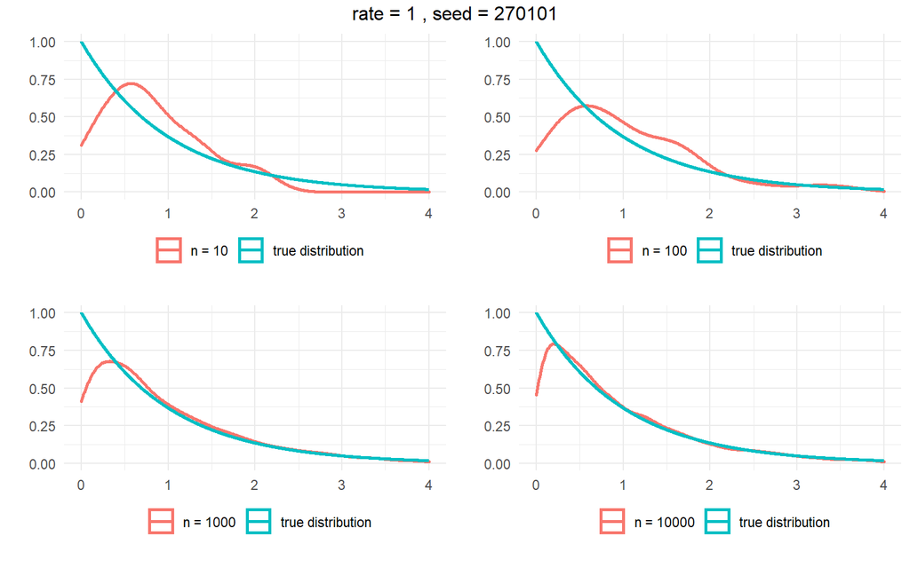

```r
expDistribution <- function(n, seed, rate, xaxis = 3, yaxis = NULL){
      if(is.null(yaxis))
            yaxis = rate
      set.seed(seed)
      data <- data.frame(x = rexp(n = n, rate = rate))
      ggplot() +
            geom_density(data = data,
                         aes(x, color = paste("n =", n)), size = 1) +
            stat_function(fun = dexp, n = 1000, args = list(rate = rate),
                                size = 1, aes(color = "true distribution")) +
            scale_x_continuous(limits = c(0, xaxis)) +
            scale_y_continuous(limits = c(0, yaxis)) +
            labs(x = "", y = "") +
            theme_minimal() +
            theme(legend.position = "bottom",
                  legend.title = element_blank(),
                  legend.box.margin = margin(-20, 0, 10, 0))
}

seed <- 270101
rate <- 1
xaxis <-  4
p1 <- expDistribution(n = 10, seed = seed, rate = rate, xaxis = xaxis)
p2 <- expDistribution(n = 100, seed = seed, rate = rate, xaxis = xaxis)
p3 <- expDistribution(n = 1000, seed = seed, rate = rate, xaxis = xaxis)
p4 <- expDistribution(n = 10000, seed = seed, rate = rate, xaxis = xaxis)

grid.arrange(p1, p2, p3, p4, nrow = 2, top = paste("rate =", rate, ", seed =", seed))
```

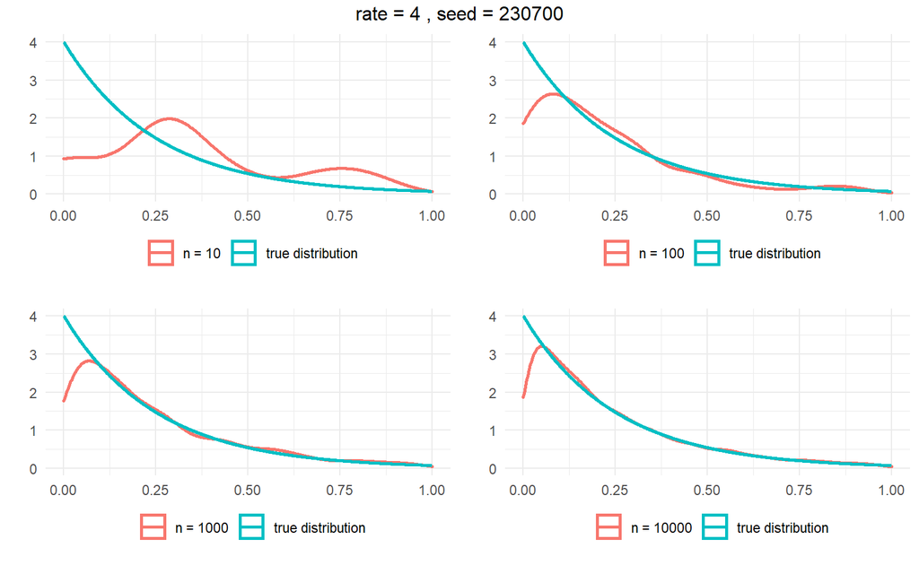

```r
seed <- 230700
rate <- 4
xaxis <- 1
p1 <- expDistribution(n = 10, seed = seed, rate = rate, xaxis = xaxis)
p2 <- expDistribution(n = 100, seed = seed, rate = rate, xaxis = xaxis)
p3 <- expDistribution(n = 1000, seed = seed, rate = rate, xaxis = xaxis)
p4 <- expDistribution(n = 10000, seed = seed, rate = rate, xaxis = xaxis)

grid.arrange(p1, p2, p3, p4, nrow = 2, top = paste("rate =", rate, ", seed =", seed))
```

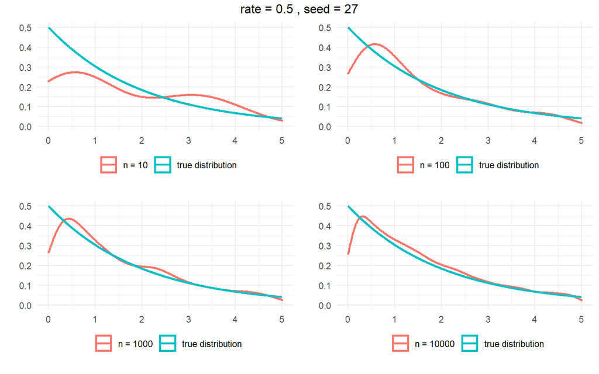

```r
seed <- 27
rate <- 0.5
xaxis <- 5
yaxis <- 0.5
p1 <- expDistribution(n = 10, seed = seed, rate = rate, xaxis = xaxis, yaxis = yaxis)
p2 <- expDistribution(n = 100, seed = seed, rate = rate, xaxis = xaxis, yaxis = yaxis)
p3 <- expDistribution(n = 1000, seed = seed, rate = rate, xaxis = xaxis, yaxis = yaxis)
p4 <- expDistribution(n = 10000, seed = seed, rate = rate, xaxis = xaxis, yaxis = yaxis)

grid.arrange(p1, p2, p3, p4, nrow = 2, top = paste("rate =", rate, ", seed =", seed))
```

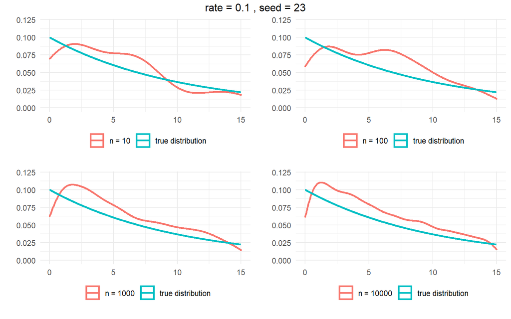

```r
seed <- 23
rate <- 0.1
xaxis <- 15
yaxis <- 0.12
p1 <- expDistribution(n = 10, seed = seed, rate = rate, xaxis = xaxis, yaxis = yaxis)
p2 <- expDistribution(n = 100, seed = seed, rate = rate, xaxis = xaxis, yaxis = yaxis)
p3 <- expDistribution(n = 1000, seed = seed, rate = rate, xaxis = xaxis, yaxis = yaxis)
p4 <- expDistribution(n = 10000, seed = seed, rate = rate, xaxis = xaxis, yaxis = yaxis)

grid.arrange(p1, p2, p3, p4, nrow = 2, top = paste("rate =", rate, ", seed =", seed))
```

## Kesimpulan

Dari beberapa plot diatas diperoleh bahwa

1. Nilai `rate` berpengaruh pada titik awal pada sumbu y, dan semakin besar maka kurvanya akan semakin menyempit, begitu pun sebaliknya.
2. Dari hasil random terlihat bahwa sangat sulit untuk membentuk kurva yang sama persis dengan distribusi aslinya, meskipun untuk nilai `n` yang sangat besar.

# Beta Distribution

## Density Function

### shape1 berubah, shape2 konstant

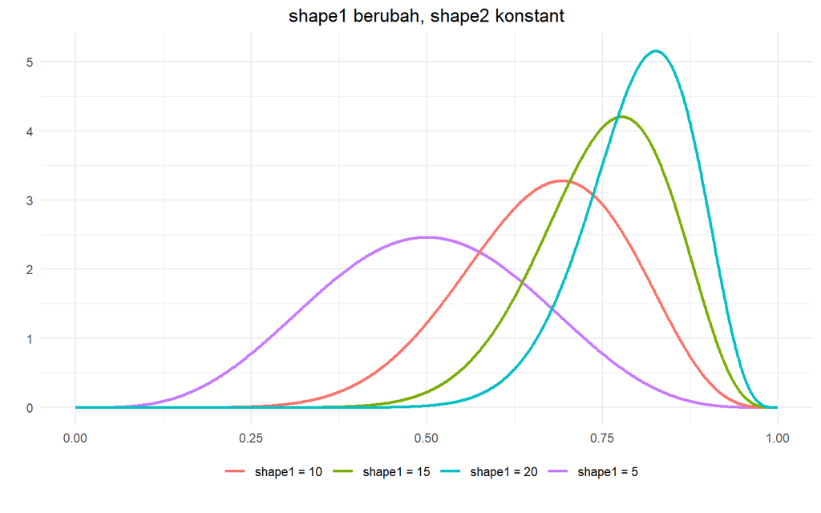

```r
ggplot(data = data.frame(x = c(0, 1)), aes(x)) +
            stat_function(fun = stats::dbeta, n = 1000, args = list(shape1 = 5, shape2 = 5),
                          size = 1, aes(color = "shape1 = 5")) +
            stat_function(fun = stats::dbeta, n = 1000, args = list(shape1 = 10, shape2 = 5),
                          size = 1, aes(color = "shape1 = 10")) +
            stat_function(fun = stats::dbeta, n = 1000, args = list(shape1 = 15, shape2 = 5),
                          size = 1, aes(color = "shape1 = 15")) +
            stat_function(fun = stats::dbeta, n = 1000, args = list(shape1 = 20, shape2 = 5),
                          size = 1, aes(color = "shape1 = 20")) +
            labs(x = "",
                 y = "",
                 title = "shape1 berubah, shape2 konstant") +
            theme_minimal() +
            theme(plot.title = element_text(hjust = 0.5),
                  legend.position = "bottom",
                  legend.title = element_blank(),
                  legend.box.margin = margin(-20, 0, 10, 0))
```

### shape1 konstant, shape2 berubah

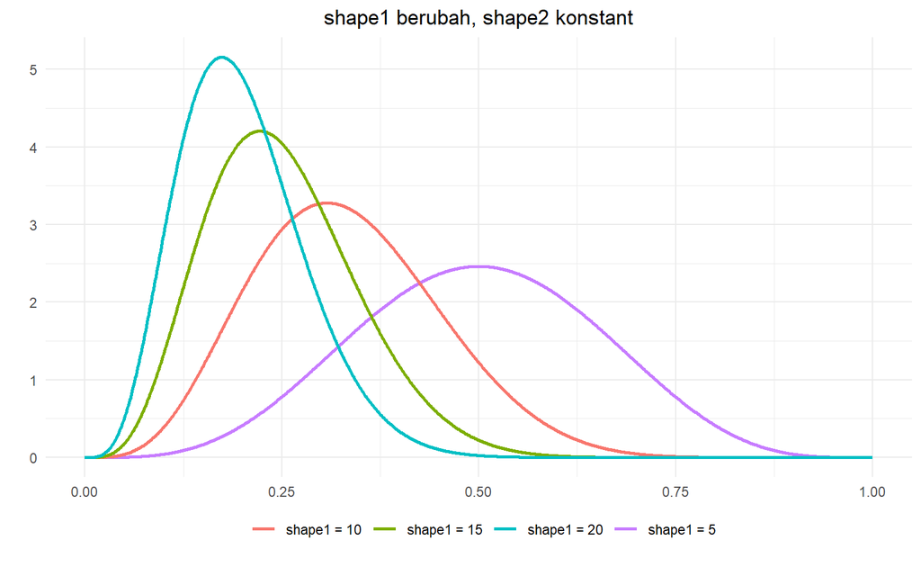

```r
ggplot(data = data.frame(x = c(0, 1)), aes(x)) +
            stat_function(fun = stats::dbeta, n = 1000, args = list(shape1 = 5, shape2 = 5),
                          size = 1, aes(color = "shape1 = 5")) +
            stat_function(fun = stats::dbeta, n = 1000, args = list(shape1 = 5, shape2 = 10),
                          size = 1, aes(color = "shape1 = 10")) +
            stat_function(fun = stats::dbeta, n = 1000, args = list(shape1 = 5, shape2 = 15),
                          size = 1, aes(color = "shape1 = 15")) +
            stat_function(fun = stats::dbeta, n = 1000, args = list(shape1 = 5, shape2 = 20),
                          size = 1, aes(color = "shape1 = 20")) +
            labs(x = "",
                 y = "",
                 title = "shape1 berubah, shape2 konstant") +
            theme_minimal() +
            theme(plot.title = element_text(hjust = 0.5),
                  legend.position = "bottom",
                  legend.title = element_blank(),
                  legend.box.margin = margin(-20, 0, 10, 0))
```

## Random Data

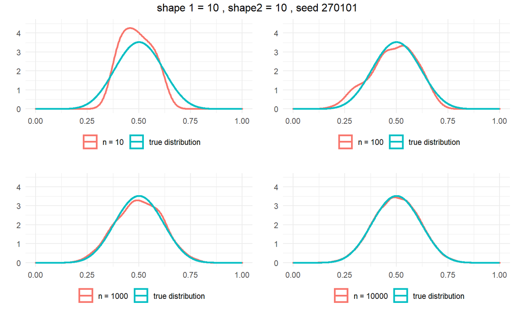

```r
betaDistribution <- function(n, seed, shape1, shape2, yaxis = 4.5){
      set.seed(seed)
      data <- data.frame(x = rbeta(n = n, shape1 = shape1, shape2 = shape2))
      ggplot() +
            geom_density(data = data,
                         aes(x, color = paste("n =", n)), size = 1) +
            stat_function(fun = stats::dbeta, n = 1000, args = list(shape1 = shape1, shape2 = shape2),
                                size = 1, aes(color = "true distribution")) +
            scale_x_continuous(limits = c(0, 1)) +
            scale_y_continuous(limits = c(0, yaxis)) +
            labs(x = "", y = "") +
            theme_minimal() +
            theme(legend.position = "bottom",
                  legend.title = element_blank(),
                  legend.box.margin = margin(-20, 0, 10, 0))
}

seed <- 270101
shape1 <- 10
shape2 <- 10
p1 <- betaDistribution(n = 10, seed = seed, shape1 = shape1, shape2 = shape2)
p2 <- betaDistribution(n = 100, seed = seed, shape1 = shape1, shape2 = shape2)
p3 <- betaDistribution(n = 1000, seed = seed, shape1 = shape1, shape2 = shape2)
p4 <- betaDistribution(n = 10000, seed = seed, shape1 = shape1, shape2 = shape2)

grid.arrange(p1, p2, p3, p4, nrow = 2, top = paste("shape 1 =", shape1, ", shape2 =", shape2, ", seed", seed))
```

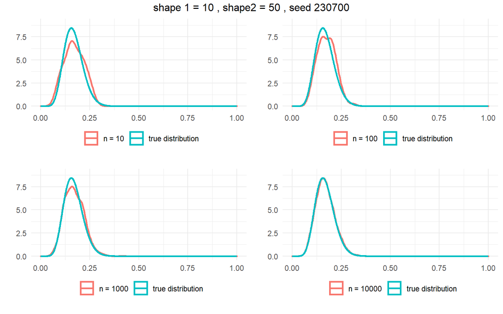

```r
seed <- 230700
shape1 <- 10
shape2 <- 50
yaxis <- 9
p1 <- betaDistribution(n = 10, seed = seed, shape1 = shape1, shape2 = shape2, yaxis = yaxis)
p2 <- betaDistribution(n = 100, seed = seed, shape1 = shape1, shape2 = shape2, yaxis = yaxis)
p3 <- betaDistribution(n = 1000, seed = seed, shape1 = shape1, shape2 = shape2, yaxis = yaxis)
p4 <- betaDistribution(n = 10000, seed = seed, shape1 = shape1, shape2 = shape2, yaxis = yaxis)

grid.arrange(p1, p2, p3, p4, nrow = 2, top = paste("shape 1 =", shape1, ", shape2 =", shape2, ", seed", seed))
```

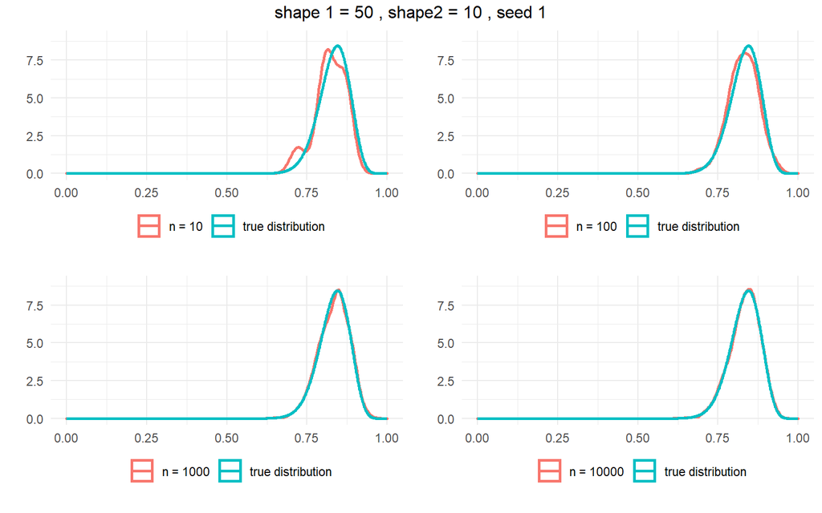

```r
seed <- 1
shape1 <- 50
shape2 <- 10
yaxis <- 9
p1 <- betaDistribution(n = 10, seed = seed, shape1 = shape1, shape2 = shape2, yaxis = yaxis)
p2 <- betaDistribution(n = 100, seed = seed, shape1 = shape1, shape2 = shape2, yaxis = yaxis)
p3 <- betaDistribution(n = 1000, seed = seed, shape1 = shape1, shape2 = shape2, yaxis = yaxis)
p4 <- betaDistribution(n = 10000, seed = seed, shape1 = shape1, shape2 = shape2, yaxis = yaxis)

grid.arrange(p1, p2, p3, p4, nrow = 2, top = paste("shape 1 =", shape1, ", shape2 =", shape2, ", seed", seed))
```

## Kesimpulan

Dari beberapa plot diatas diperoleh bahwa

1. Distribusi `beta` sangat dipengaruhi oleh nilai parameter `shape1` dan `shape2`
2. Ketika `shape1 = shape2` maka kurvanya akan menyerupai normal. Ketika `shape1 < shaape2` kurvanya menceng kanan. Ketika `shape1 > shape2` kurvanya menceng kiri.
3. Untuk data bangkitan, akan stabil mengikuti kurva yang sebenarnya ketika n mencapai ribuan

# Uniform Distribution

## Density Function

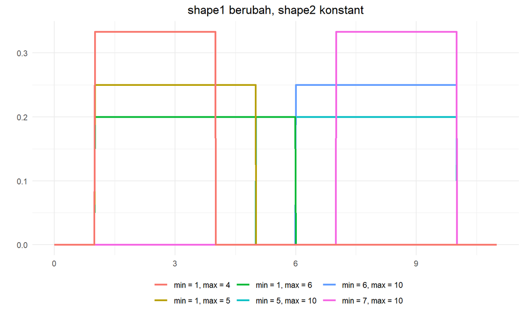

```r
ggplot(data = data.frame(x = c(0, 11)), aes(x)) +
            stat_function(fun = stats::dunif, n = 1000, args = list(min = 5, max = 10),
                          size = 1, aes(color = "min = 5, max = 10")) +
            stat_function(fun = stats::dunif, n = 1000, args = list(min = 6, max = 10),
                          size = 1, aes(color = "min = 6, max = 10")) +
            stat_function(fun = stats::dunif, n = 1000, args = list(min = 7, max = 10),
                          size = 1, aes(color = "min = 7, max = 10")) +
            stat_function(fun = stats::dunif, n = 1000, args = list(min = 1, max = 6),
                          size = 1, aes(color = "min = 1, max = 6")) +
            stat_function(fun = stats::dunif, n = 1000, args = list(min = 1, max = 5),
                          size = 1, aes(color = "min = 1, max = 5")) +
            stat_function(fun = stats::dunif, n = 1000, args = list(min = 1, max = 4),
                          size = 1, aes(color = "min = 1, max = 4")) +
            labs(x = "",
                 y = "",
                 title = "shape1 berubah, shape2 konstant") +
            theme_minimal() +
            theme(plot.title = element_text(hjust = 0.5),
                  legend.position = "bottom",
                  legend.title = element_blank(),
                  legend.box.margin = margin(-20, 0, 10, 0))
```

## Random Data

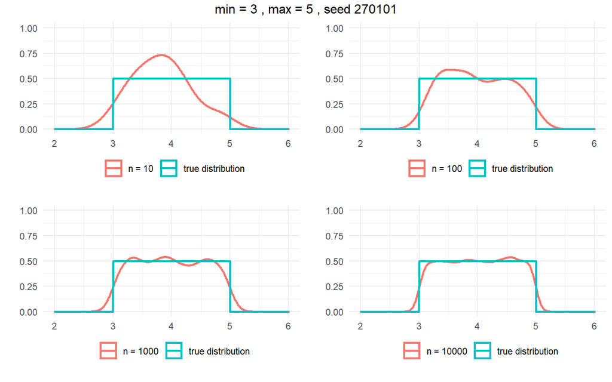

```r
unifDistribution <- function(n, seed, min, max, yaxis = 1){
      set.seed(seed)
      data <- data.frame(x = runif(n = n, min = min, max = max))
      ggplot() +
            geom_density(data = data,
                         aes(x, color = paste("n =", n)), size = 1) +
            stat_function(fun = stats::dunif, n = 1000, args = list(min = min, max = max),
                                size = 1, aes(color = "true distribution")) +
            scale_x_continuous(limits = c(min - 1, max + 1)) +
            scale_y_continuous(limits = c(0, yaxis)) +
            labs(x = "", y = "") +
            theme_minimal() +
            theme(legend.position = "bottom",
                  legend.title = element_blank(),
                  legend.box.margin = margin(-20, 0, 10, 0))
}

seed <- 270101
min <- 3
max <- 5
p1 <- unifDistribution(n = 10, seed = seed, min = min, max = max)
p2 <- unifDistribution(n = 100, seed = seed, min = min, max = max)
p3 <- unifDistribution(n = 1000, seed = seed, min = min, max = max)
p4 <- unifDistribution(n = 10000, seed = seed, min = min, max = max)

grid.arrange(p1, p2, p3, p4, nrow = 2, top = paste("min =", min, ", max =", max, ", seed", seed))
```

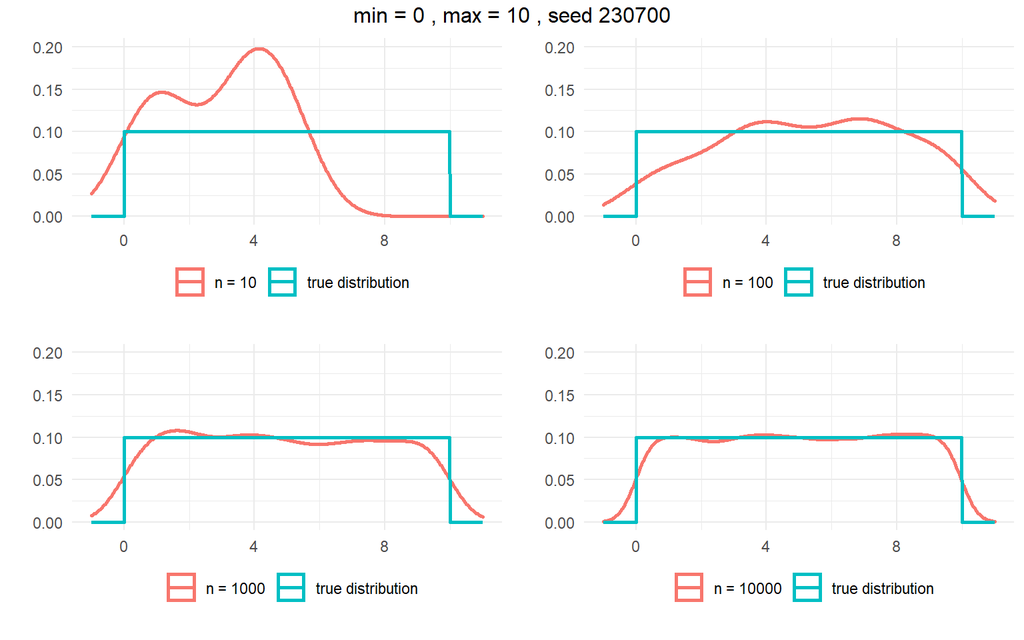

```r
seed <- 230700
min <- 0
max <- 10
yaxis <- 0.2
p1 <- unifDistribution(n = 10, seed = seed, min = min, max = max, yaxis = yaxis)
p2 <- unifDistribution(n = 100, seed = seed, min = min, max = max, yaxis = yaxis)
p3 <- unifDistribution(n = 1000, seed = seed, min = min, max = max, yaxis = yaxis)
p4 <- unifDistribution(n = 10000, seed = seed, min = min, max = max, yaxis = yaxis)

grid.arrange(p1, p2, p3, p4, nrow = 2, top = paste("min =", min, ", max =", max, ", seed", seed))
```

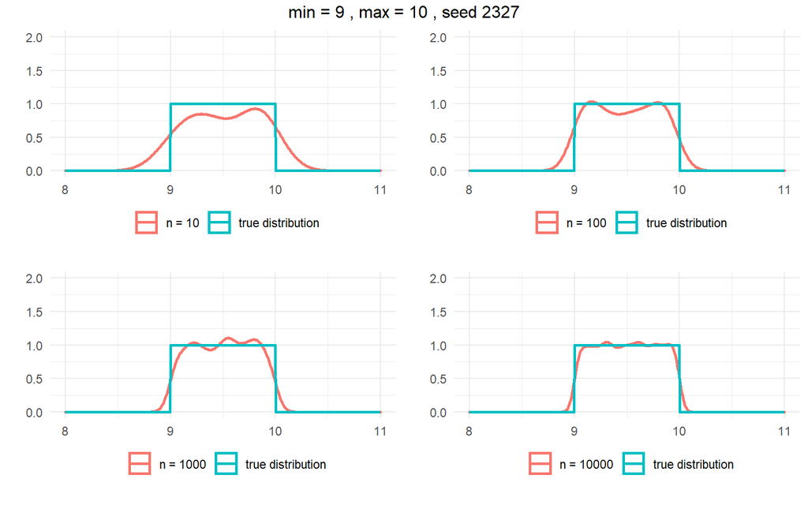

```r
seed <- 2327
min <- 9
max <- 10
yaxis <- 2
p1 <- unifDistribution(n = 10, seed = seed, min = min, max = max, yaxis = yaxis)
p2 <- unifDistribution(n = 100, seed = seed, min = min, max = max, yaxis = yaxis)
p3 <- unifDistribution(n = 1000, seed = seed, min = min, max = max, yaxis = yaxis)
p4 <- unifDistribution(n = 10000, seed = seed, min = min, max = max, yaxis = yaxis)

grid.arrange(p1, p2, p3, p4, nrow = 2, top = paste("min =", min, ", max =", max, ", seed", seed))
```

## Kesimpulan

Dari beberapa plot diatas diperoleh bahwa

1. Bentuk kurvanya hanya garis lurus dari `min` hingga `max`.
2. Letak kurva disumbu y sangat bergantung pada range nilai `min` dan `max`. Ketika rangenya kecil maka akan semakin tinggi, begitu pun sebaliknya.
3. Untuk data random sangat sulit untuk membangkitkan yang sesuai dengan distribusinya, meskipun untuk nilai n yang sangat besar.

# Logistic Distribution

## Density Function

### location constant, scale berubah

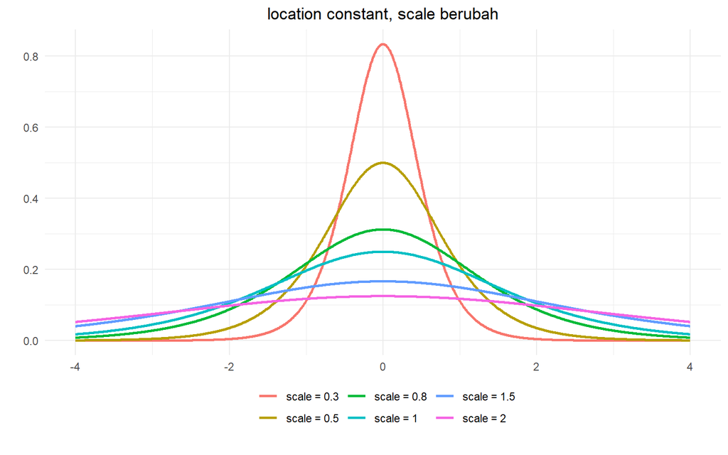

```r
ggplot(data = data.frame(x = c(-4, 4)), aes(x)) +
            stat_function(fun = stats::dlogis, n = 1000, args = list(location = 0, scale = 0.3),
                          size = 1, aes(color = "scale = 0.3")) +
            stat_function(fun = stats::dlogis, n = 1000, args = list(location = 0, scale = 0.5),
                          size = 1, aes(color = "scale = 0.5")) +
            stat_function(fun = stats::dlogis, n = 1000, args = list(location = 0, scale = 0.8),
                          size = 1, aes(color = "scale = 0.8")) +
            stat_function(fun = stats::dlogis, n = 1000, args = list(location = 0, scale = 1),
                          size = 1, aes(color = "scale = 1")) +
            stat_function(fun = stats::dlogis, n = 1000, args = list(location = 0, scale = 1.5),
                          size = 1, aes(color = "scale = 1.5")) +
            stat_function(fun = stats::dlogis, n = 1000, args = list(location = 0, scale = 2),
                          size = 1, aes(color = "scale = 2")) +
            labs(x = "",
                 y = "",
                 title = "location constant, scale berubah") +
            theme_minimal() +
            theme(plot.title = element_text(hjust = 0.5),
                  legend.position = "bottom",
                  legend.title = element_blank(),
                  legend.box.margin = margin(-20, 0, 10, 0))
```

### location berubah, scale constant

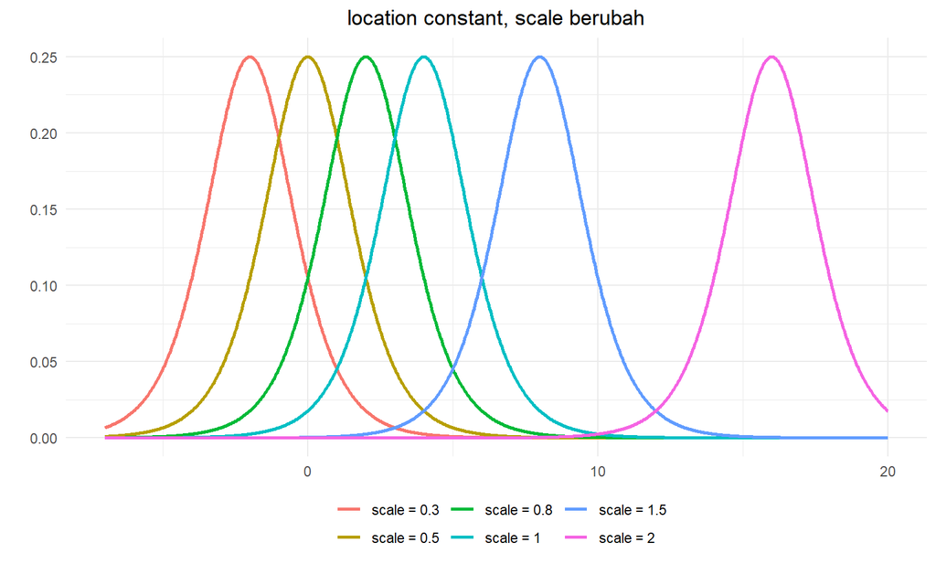

```r
ggplot(data = data.frame(x = c(-7, 20)), aes(x)) +
            stat_function(fun = stats::dlogis, n = 1000, args = list(location = -2, scale = 1),
                          size = 1, aes(color = "scale = 0.3")) +
            stat_function(fun = stats::dlogis, n = 1000, args = list(location = 0, scale = 1),
                          size = 1, aes(color = "scale = 0.5")) +
            stat_function(fun = stats::dlogis, n = 1000, args = list(location = 2, scale = 1),
                          size = 1, aes(color = "scale = 0.8")) +
            stat_function(fun = stats::dlogis, n = 1000, args = list(location = 4, scale = 1),
                          size = 1, aes(color = "scale = 1")) +
            stat_function(fun = stats::dlogis, n = 1000, args = list(location = 8, scale = 1),
                          size = 1, aes(color = "scale = 1.5")) +
            stat_function(fun = stats::dlogis, n = 1000, args = list(location = 16, scale = 1),
                          size = 1, aes(color = "scale = 2")) +
            labs(x = "",
                 y = "",
                 title = "location constant, scale berubah") +
            theme_minimal() +
            theme(plot.title = element_text(hjust = 0.5),
                  legend.position = "bottom",
                  legend.title = element_blank(),
                  legend.box.margin = margin(-20, 0, 10, 0))
```

## Random Data

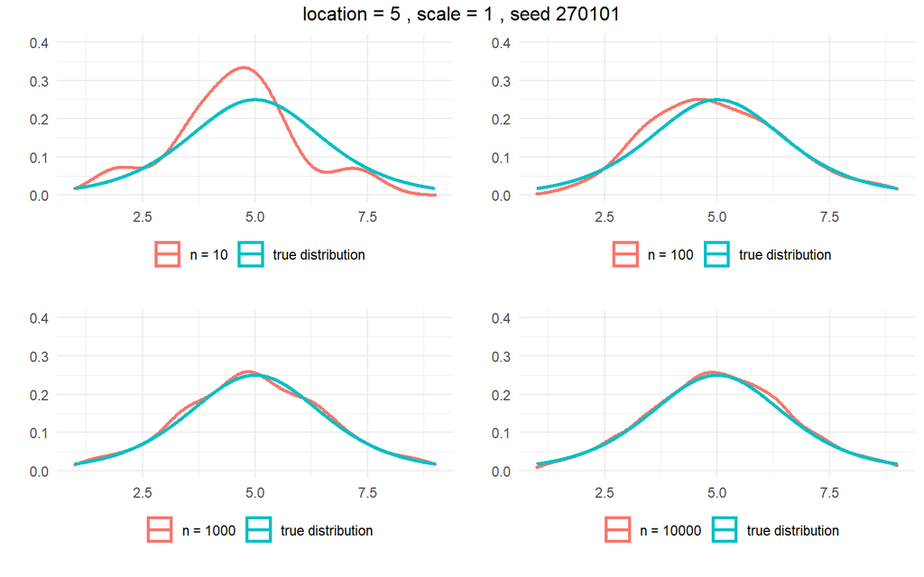

```r
logisDistribution <- function(n, seed, location, scale, yaxis = 1, xaxis = 4){
      set.seed(seed)
      data <- data.frame(x = rlogis(n = n, location = location, scale = scale))
      ggplot() +
            geom_density(data = data,
                         aes(x, color = paste("n =", n)), size = 1) +
            stat_function(fun = stats::dlogis, n = 1000, args = list(location = location, scale = scale),
                                size = 1, aes(color = "true distribution")) +
            scale_x_continuous(limits = c(location - xaxis, location + xaxis)) +
            scale_y_continuous(limits = c(0, yaxis)) +
            labs(x = "", y = "") +
            theme_minimal() +
            theme(legend.position = "bottom",
                  legend.title = element_blank(),
                  legend.box.margin = margin(-20, 0, 10, 0))
}

seed <- 270101
location <- 5
scale <- 1
yaxis <- 0.4
xaxis <- 4
p1 <- logisDistribution(n = 10, seed = seed, location = location, scale = scale, yaxis = yaxis, xaxis = xaxis)
p2 <- logisDistribution(n = 100, seed = seed, location = location, scale = scale, yaxis = yaxis, xaxis = xaxis)
p3 <- logisDistribution(n = 1000, seed = seed, location = location, scale = scale, yaxis = yaxis, xaxis = xaxis)
p4 <- logisDistribution(n = 10000, seed = seed, location = location, scale = scale, yaxis = yaxis, xaxis = xaxis)

grid.arrange(p1, p2, p3, p4, nrow = 2, top = paste("location =", location, ", scale =", scale, ", seed", seed))
```

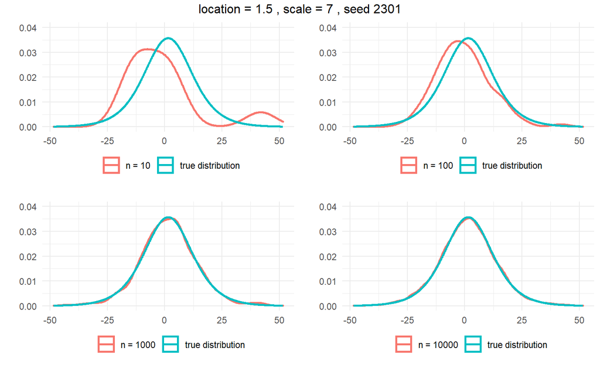

```r
seed <- 2301
location <- 1.5
scale <- 7
yaxis <- 0.040
xaxis <- 50
p1 <- logisDistribution(n = 10, seed = seed, location = location, scale = scale, yaxis = yaxis, xaxis = xaxis)
p2 <- logisDistribution(n = 100, seed = seed, location = location, scale = scale, yaxis = yaxis, xaxis = xaxis)
p3 <- logisDistribution(n = 1000, seed = seed, location = location, scale = scale, yaxis = yaxis, xaxis = xaxis)
p4 <- logisDistribution(n = 10000, seed = seed, location = location, scale = scale, yaxis = yaxis, xaxis = xaxis)

grid.arrange(p1, p2, p3, p4, nrow = 2, top = paste("location =", location, ", scale =", scale, ", seed", seed))
```

## Kesimpulan

Dari beberapa plot diperoleh bahwa 1. Nilai `scale` berpengaruh pada keruncingan kurva dan `location` berpengaruh pada pusat dari kurva. Jika diliat plotnya cukup mirip dengan normal distribution 2. Untuk data bangkitan ketika `n` mencapai hasil bangkitannya sudah cukup mengikuti distribusi aslinya.

# Binomial Distribution

## Density Function

### Size konstant, p berubah

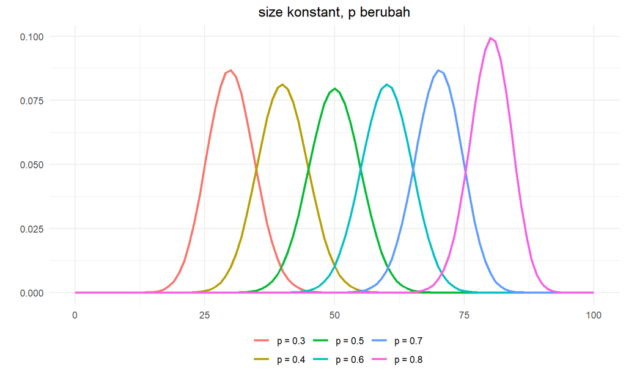

```r
size <- 100
data <- data.frame(x1 = 0:size, y1 = dbinom(0:size, size = size, p = 0.3),
                   x2 = 0:size, y2 = dbinom(0:size, size = size, p = 0.4),
                   x3 = 0:size, y3 = dbinom(0:size, size = size, p = 0.5),
                   x4 = 0:size, y4 = dbinom(0:size, size = size, p = 0.6),
                   x5 = 0:size, y5 = dbinom(0:size, size = size, p = 0.7),
                   x6 = 0:size, y6 = dbinom(0:size, size = size, p = 0.8))

ggplot(data = data) +
      geom_line(aes(x1, y1, color = paste("p =", 0.3)), size = 1) +
      geom_line(aes(x2, y2, color = paste("p =", 0.4)), size = 1) +
      geom_line(aes(x3, y3, color = paste("p =", 0.5)), size = 1) +
      geom_line(aes(x4, y4, color = paste("p =", 0.6)), size = 1) +
      geom_line(aes(x5, y5, color = paste("p =", 0.7)), size = 1) +
      geom_line(aes(x6, y6, color = paste("p =", 0.8)), size = 1) +
      scale_x_continuous(limits = c(0, size)) +
      labs(x = "", y = "", title = "size konstant, p berubah") +
      theme_minimal() +
      theme(plot.title = element_text(hjust = 0.5),
            legend.position = "bottom",
            legend.title = element_blank(),
            legend.box.margin = margin(-20, 0, 10, 0))
```

### Size berubah, p konstant

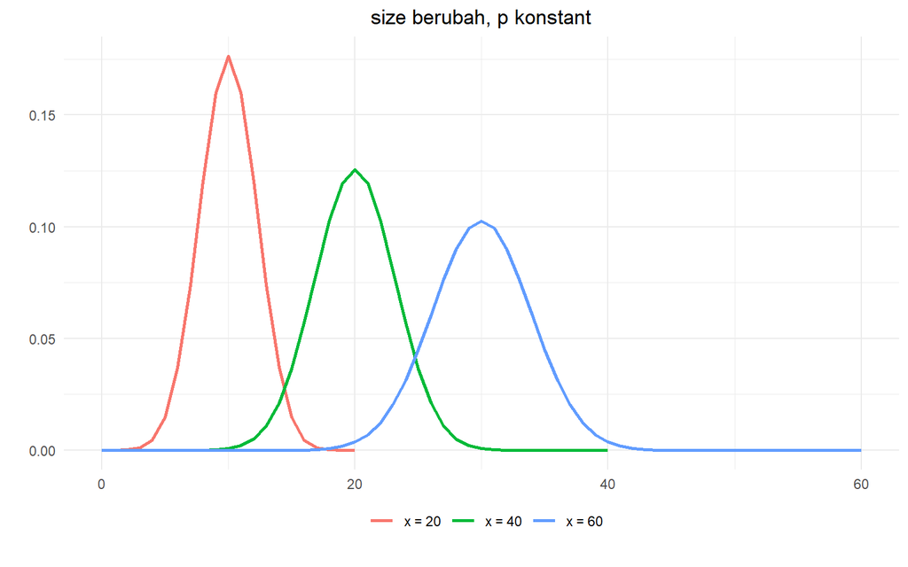

```r
ggplot() +
      geom_line(data = data.frame(x = 0:20, y = dbinom(0:20, size = 20, p = 0.5)),
                aes(x, y, color = paste("x =", 20)), size = 1) +
      geom_line(data = data.frame(x = 0:40, y = dbinom(0:40, size = 40, p = 0.5)),
                aes(x, y, color = paste("x =", 40)), size = 1) +
      geom_line(data = data.frame(x = 0:60, y = dbinom(0:60, size = 60, p = 0.5)),
                aes(x, y, color = paste("x =", 60)), size = 1) +
      scale_x_continuous(limits = c(0, 60)) +
      labs(x = "", y = "", title = "size berubah, p konstant") +
      theme_minimal() +
      theme(plot.title = element_text(hjust = 0.5),
            legend.position = "bottom",
            legend.title = element_blank(),
            legend.box.margin = margin(-20, 0, 10, 0))
```

## Data Random

```r
pCum <- function(x){
      data.frame(table(x)) %>%
            mutate(x = as.integer(as.character(x)),
                   p = Freq/sum(Freq)) %>%
            select(x, p)
}
```

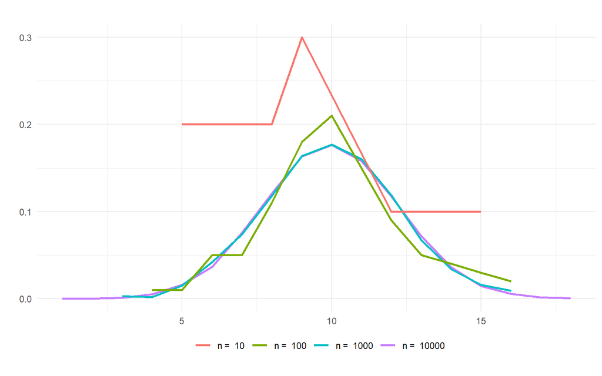

```r
set.seed(27)
ggplot() +
      geom_line(data = pCum(data.frame(x = rbinom(10000, 20, 0.5))), aes(x, p, color = "n =  10000"), size = 1) +
      geom_line(data = pCum(data.frame(x = rbinom(1000, 20, 0.5))), aes(x, p, color = "n =  1000"), size = 1) +
      geom_line(data = pCum(data.frame(x = rbinom(100, 20, 0.5))), aes(x, p, color = "n =  100"), size = 1) +
      geom_line(data = pCum(data.frame(x = rbinom(10, 20, 0.5))), aes(x, p, color = "n =  10"), size = 1) +
      labs(x = "", y = "", title = "") +
      theme_minimal() +
      theme(plot.title = element_text(hjust = 0.5),
            legend.position = "bottom",
            legend.title = element_blank(),
            legend.box.margin = margin(-20, 0, 10, 0))
```

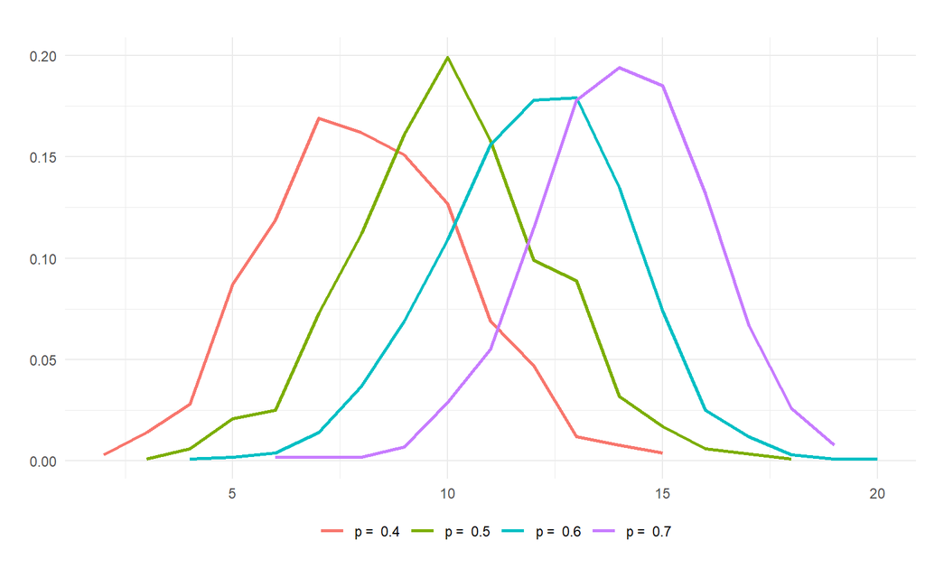

```r
set.seed(27)
ggplot() +
      geom_line(data = pCum(data.frame(x = rbinom(1000, 20, 0.4))), aes(x, p, color = "p =  0.4"), size = 1) +
      geom_line(data = pCum(data.frame(x = rbinom(1000, 20, 0.5))), aes(x, p, color = "p =  0.5"), size = 1) +
      geom_line(data = pCum(data.frame(x = rbinom(1000, 20, 0.6))), aes(x, p, color = "p =  0.6"), size = 1) +
      geom_line(data = pCum(data.frame(x = rbinom(1000, 20, 0.7))), aes(x, p, color = "p =  0.7"), size = 1) +
      labs(x = "", y = "", title = "") +
      theme_minimal() +
      theme(plot.title = element_text(hjust = 0.5),
            legend.position = "bottom",
            legend.title = element_blank(),
            legend.box.margin = margin(-20, 0, 10, 0))
```

## Kesimpulan

Dari beberapa plot diatas diperoleh bahwa

1. Nilai `size` akan berpengaruh pada lebar dari kurva. Misalnya untuk `size = 60` maka kurvanya ada pada titik 1-60 dan akan memiliki puncak sesuai dengan nilai `p`
2. Ketika `p > 0.5` maka data akan menceng ke kiri dan ketika `p < 0.5` maka data akan menceng kanan.
3. Untuk `n < 100` bentuk kurvaya masih jauh dari bentuk distribusinya.

# Poisson Distribution

## Density Function

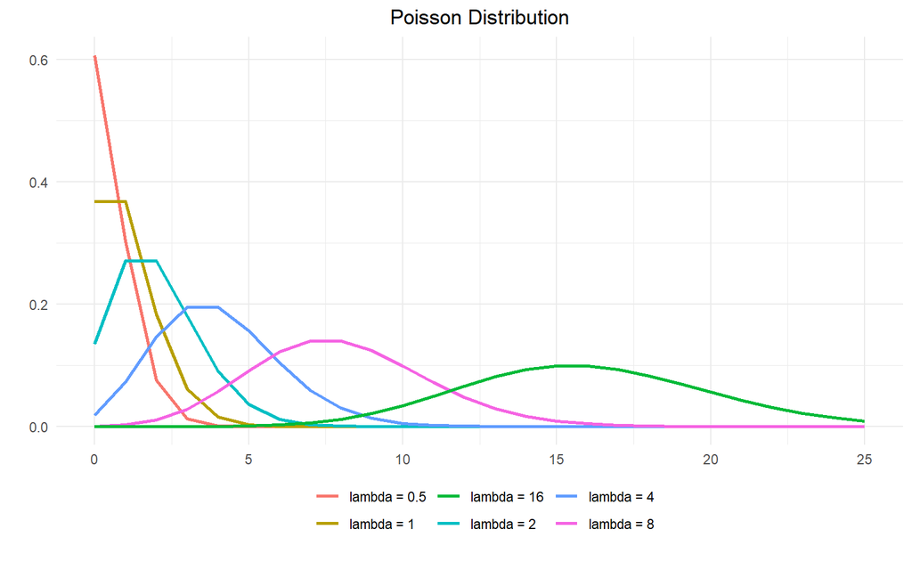

```r
data <- data.frame(x1 = 0:25, y1 = dpois(0:25, 0.5),
                   x2 = 0:25, y2 = dpois(0:25, 1),
                   x3 = 0:25, y3 = dpois(0:25, 2),
                   x4 = 0:25, y4 = dpois(0:25, 4),
                   x5 = 0:25, y5 = dpois(0:25, 8),
                   x6 = 0:25, y6 = dpois(0:25, 16))

ggplot(data = data) +
      geom_line(aes(x1, y1, color = paste("lambda =", 0.5)), size = 1) +
      geom_line(aes(x2, y2, color = paste("lambda =", 1)), size = 1) +
      geom_line(aes(x3, y3, color = paste("lambda =", 2)), size = 1) +
      geom_line(aes(x4, y4, color = paste("lambda =", 4)), size = 1) +
      geom_line(aes(x5, y5, color = paste("lambda =", 8)), size = 1) +
      geom_line(aes(x6, y6, color = paste("lambda =", 16)), size = 1) +
      scale_x_continuous(limits = c(0, 25)) +
      labs(x = "", y = "", title = "Poisson Distribution") +
      theme_minimal() +
      theme(plot.title = element_text(hjust = 0.5),
            legend.position = "bottom",
            legend.title = element_blank(),
            legend.box.margin = margin(-20, 0, 10, 0))
```

## Random Data

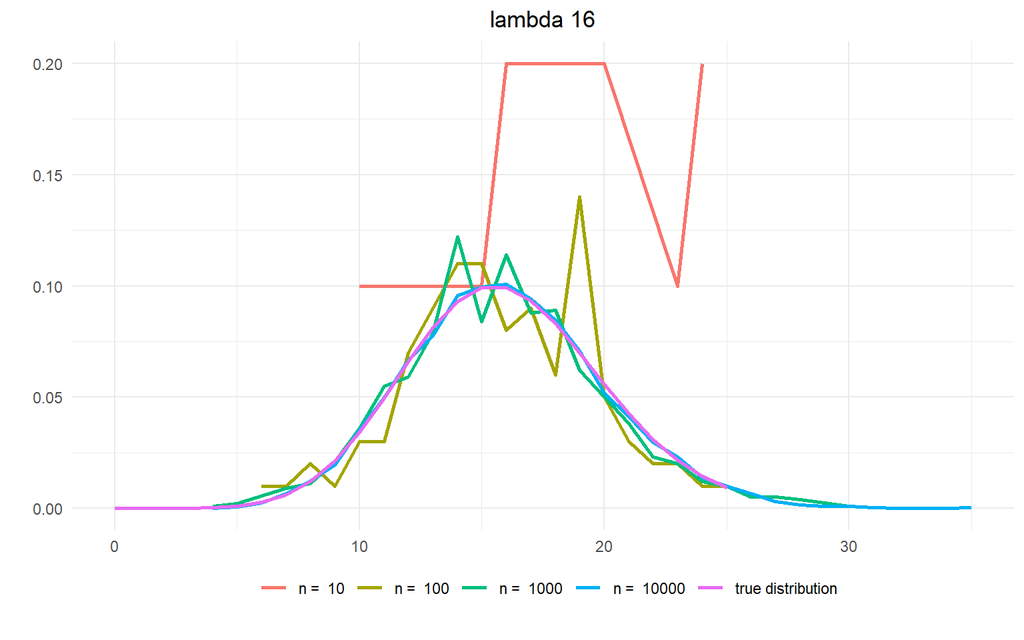

```r
set.seed(27)
ggplot() +
      geom_line(data = pCum(data.frame(x = rpois(10, lambda = 16))), aes(x, p, color = "n =  10"), size = 1) +
      geom_line(data = pCum(data.frame(x = rpois(100, lambda = 16))), aes(x, p, color = "n =  100"), size = 1) +
      geom_line(data = pCum(data.frame(x = rpois(1000, lambda = 16))), aes(x, p, color = "n =  1000"), size = 1) +
      geom_line(data = pCum(data.frame(x = rpois(10000, lambda = 16))), aes(x, p, color = "n =  10000"), size = 1) +
      geom_line(data = data.frame(x6 = 0:25, y6 = dpois(0:25, 16)),
             aes(x6, y6, color = "true distribution"), size = 1) +
      labs(x = "", y = "", title = "lambda 16") +
      theme_minimal() +
      theme(plot.title = element_text(hjust = 0.5),
            legend.position = "bottom",
            legend.title = element_blank(),
            legend.box.margin = margin(-20, 0, 10, 0))
```

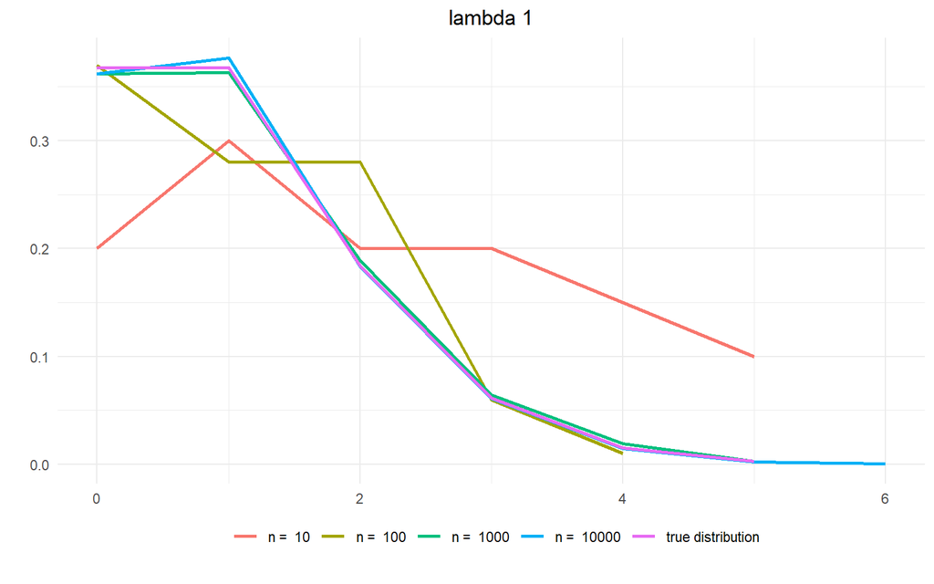

```r
set.seed(23)
ggplot() +
      geom_line(data = pCum(data.frame(x = rpois(10, lambda = 1))), aes(x, p, color = "n =  10"), size = 1) +
      geom_line(data = pCum(data.frame(x = rpois(100, lambda = 1))), aes(x, p, color = "n =  100"), size = 1) +
      geom_line(data = pCum(data.frame(x = rpois(1000, lambda = 1))), aes(x, p, color = "n =  1000"), size = 1) +
      geom_line(data = pCum(data.frame(x = rpois(10000, lambda = 1))), aes(x, p, color = "n =  10000"), size = 1) +
      geom_line(data = data.frame(x6 = 0:5, y6 = dpois(0:5, 1)),
             aes(x6, y6, color = "true distribution"), size = 1) +
      labs(x = "", y = "", title = "lambda 1") +
      theme_minimal() +
      theme(plot.title = element_text(hjust = 0.5),
            legend.position = "bottom",
            legend.title = element_blank(),
            legend.box.margin = margin(-20, 0, 10, 0))
```

## Kesimpulan

Dari beberapa plot diatas diperoleh bahwa

1. Terlihat bahwa nilai `lambda` berpengaruh pada bentuk kurva. Semakin kecil nilainya puncaknya akan mendekati titik 0 pada sumbu x. Sebaliknya semakin besar maka puncaknya semakin menjauh titik 0 pada sumbu y.
2. Data bangkitan akan menyerupai disribusi sebenarnya ketika n mencapai puluhan ribu.

# Geometrik Distribution

## Density Function

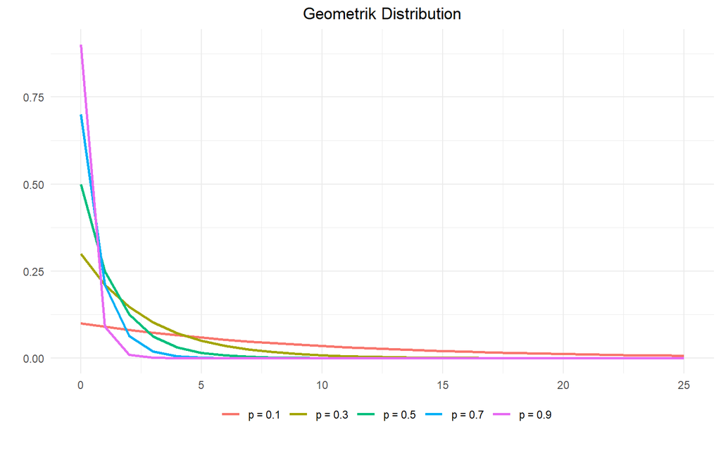

```r
data <- data.frame(x1 = 0:25, y1 = dgeom(0:25, 0.1),
                   x2 = 0:25, y2 = dgeom(0:25, 0.3),
                   x3 = 0:25, y3 = dgeom(0:25, 0.5),
                   x4 = 0:25, y4 = dgeom(0:25, 0.7),
                   x5 = 0:25, y5 = dgeom(0:25, 0.9))

ggplot(data = data) +
      geom_line(aes(x1, y1, color = paste("p =", 0.1)), size = 1) +
      geom_line(aes(x2, y2, color = paste("p =", 0.3)), size = 1) +
      geom_line(aes(x3, y3, color = paste("p =", 0.5)), size = 1) +
      geom_line(aes(x4, y4, color = paste("p =", 0.7)), size = 1) +
      geom_line(aes(x5, y5, color = paste("p =", 0.9)), size = 1) +
      scale_x_continuous(limits = c(0, 25)) +
      labs(x = "", y = "", title = "Geometrik Distribution") +
      theme_minimal() +
      theme(plot.title = element_text(hjust = 0.5),
            legend.position = "bottom",
            legend.title = element_blank(),
            legend.box.margin = margin(-20, 0, 10, 0))
```

## Random Data

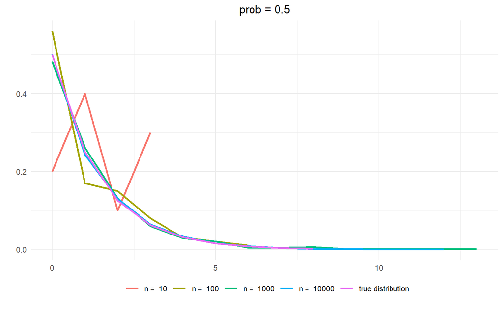

```r
set.seed(27)
ggplot() +
      geom_line(data = pCum(data.frame(x = rgeom(10, 0.5))), aes(x, p, color = "n =  10"), size = 1) +
      geom_line(data = pCum(data.frame(x = rgeom(100, 0.5))), aes(x, p, color = "n =  100"), size = 1) +
      geom_line(data = pCum(data.frame(x = rgeom(1000, 0.5))), aes(x, p, color = "n =  1000"), size = 1) +
      geom_line(data = pCum(data.frame(x = rgeom(10000, 0.5))), aes(x, p, color = "n =  10000"), size = 1) +
      geom_line(data = data.frame(x3 = 0:8, y3 = dgeom(0:8, 0.5)),
             aes(x3, y3, color = "true distribution"), size = 1) +
      labs(x = "", y = "", title = "prob = 0.5") +
      theme_minimal() +
      theme(plot.title = element_text(hjust = 0.5),
            legend.position = "bottom",
            legend.title = element_blank(),
            legend.box.margin = margin(-20, 0, 10, 0))
```

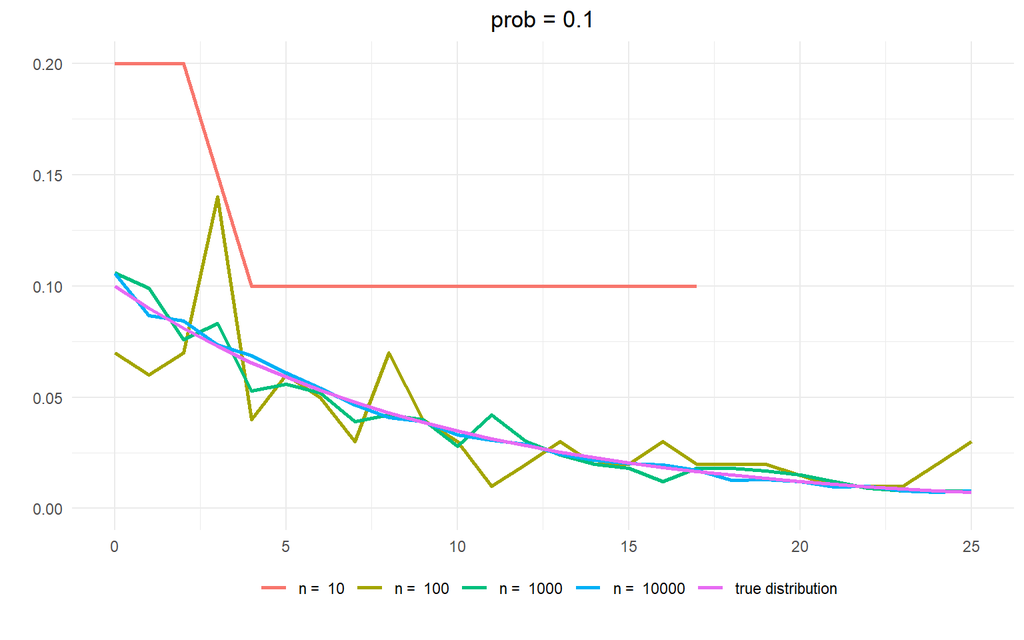

```r
set.seed(23)
ggplot() +
      geom_line(data = pCum(data.frame(x = rgeom(10, 0.1))), aes(x, p, color = "n =  10"), size = 1) +
      geom_line(data = pCum(data.frame(x = rgeom(100, 0.1))), aes(x, p, color = "n =  100"), size = 1) +
      geom_line(data = pCum(data.frame(x = rgeom(1000, 0.1))), aes(x, p, color = "n =  1000"), size = 1) +
      geom_line(data = pCum(data.frame(x = rgeom(10000, 0.1))), aes(x, p, color = "n =  10000"), size = 1) +
      geom_line(data = data.frame(x3 = 0:25, y3 = dgeom(0:25, 0.1)),
             aes(x3, y3, color = "true distribution"), size = 1) +
      scale_x_continuous(limits = c(0, 25)) +
      labs(x = "", y = "", title = "prob = 0.1") +
      theme_minimal() +
      theme(plot.title = element_text(hjust = 0.5),
            legend.position = "bottom",
            legend.title = element_blank(),
            legend.box.margin = margin(-20, 0, 10, 0))
```

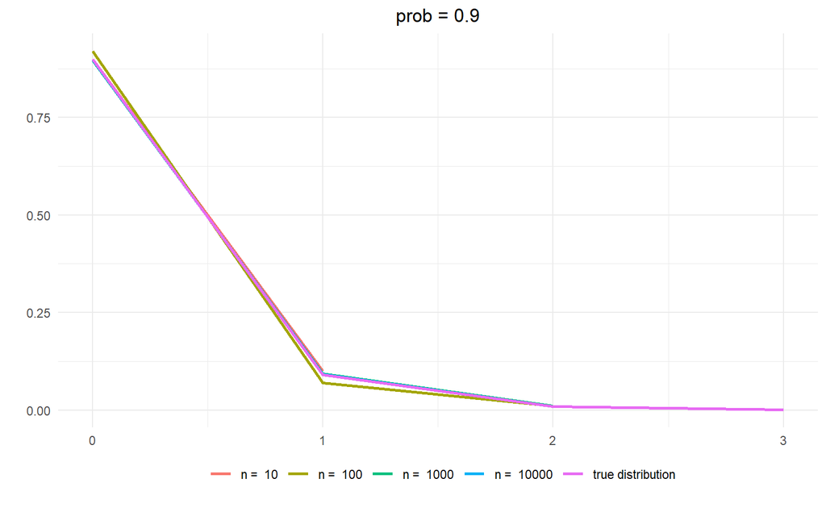

```r
set.seed(23)
ggplot() +
      geom_line(data = pCum(data.frame(x = rgeom(10, 0.9))), aes(x, p, color = "n =  10"), size = 1) +
      geom_line(data = pCum(data.frame(x = rgeom(100, 0.9))), aes(x, p, color = "n =  100"), size = 1) +
      geom_line(data = pCum(data.frame(x = rgeom(1000, 0.9))), aes(x, p, color = "n =  1000"), size = 1) +
      geom_line(data = pCum(data.frame(x = rgeom(10000, 0.9))), aes(x, p, color = "n =  10000"), size = 1) +
      geom_line(data = data.frame(x3 = 0:3, y3 = dgeom(0:3, 0.9)),
             aes(x3, y3, color = "true distribution"), size = 1) +
      labs(x = "", y = "", title = "prob = 0.9") +
      theme_minimal() +
      theme(plot.title = element_text(hjust = 0.5),
            legend.position = "bottom",
            legend.title = element_blank(),
            legend.box.margin = margin(-20, 0, 10, 0))
```

## Kesimpulan

Dari beberapa plot diatas diperoleh bahwa

1. Nilai `prob` berpengaruh pada plot. Semakin besar nilai `prob`, kurva dimulai dari sumbu y pada titik mendekati 1 kemudian melandai.
2. Untuk nilai `prob` yang besar dengan jumlah `n` yang kecil angka random yang diperoleh sudah memiliki kurva yang sangat mirip dengan distribusi sebenarnya. Semakin kecil nilai `prob` maka diperlukan semakain besar nilai `n`.